# How Does Carbon Footprint Information Affect Consumer Choice? Power Analysis

The authors of Beyer et al. (TBD)

2021-12-20, v 0.6

### Setting Simulation Parameters

These parameters determine how the simulated sample will be generated. They are based on information that we received from the canteen operator and subject to change. CO2 equivalent measures are based on kgCO2e/kg food.

```r
if (FALSE) {
  # To verify the CO2 values for parameter list
  food_co2 <- read_csv("../data/external/food_co2e.csv", col_types = cols())
  food_co2 %>%  mutate(meat_fish = category %in% c("meat", "fish")) %>%
    group_by(meat_fish) %>%
    summarise(mn_co2 = mean(co2_100g)/100, sd_co2 = sd(co2_100g)/100)
}


parms <- list(
  days = 10,
  treatment_slots_per_day = 2,
  mn_diners_per_day = 3250,
  sd_diners_per_day = 100,
  friday_churn = 0.75,
  monday_churn = 0.9,
  mn_mn_food_weight = 500,
  sd_mn_food_weight = 50,
  mn_sd_food_weight = 160,
  sd_sd_food_weight = 10,
  prob_meat_fish = 0.5,
  sd_meat_fish = 0.1,
  mn_mtfsh_weight = 200,
  sd_mtfsh_weight = 50,
  mn_co2e_veg = 2.2,
  sd_co2e_veg = 2.2,
  mn_co2e_mtfsh = 8.7,
  sd_co2e_mtfsh = 11.0
)
```

### Setting up meal plan

We simulate a meal plan that contains two dishes: Vegetarian and Meat/Fish. Diners can choose whether they add a meat/fish component to their otherwise vegetarian dish. If they do, then the `meat_fish` indicator variable in the diner dataset is being set to true.

```r
# We need to truncate the mtfsh and vegetable CO2 distribution to enforce
# that mtfsh always has higher CO2 equivalent per 100g than vegetables
# In the field, this will be verified by food menue design.

sim_meal_plan <- function() {
  tibble(
    day = 1:parms$days,
    veg_co2e = rtruncnorm(
      parms$days, 0.2, 3, mean = parms$mn_co2e_veg, sd = parms$sd_co2e_veg
    ),
    mtfsh_co2e = rtruncnorm(
      parms$days, 4, mean = parms$mn_co2e_mtfsh, sd = parms$sd_co2e_mtfsh
    ),
    mtfsh_weight = rtruncnorm(
      parms$days, 100, mean = parms$mn_mtfsh_weight, sd = parms$sd_mtfsh_weight
    )
  )
}

meal_plan <- sim_meal_plan()
```

### Base Sample Descriptives

This is a draw of our base sample (without any treatment)

```r
df <- sim_base_sample(parms, meal_plan)

kable(
  df %>% group_by(day) %>%
    summarise(
      diners = n(),
      meat_fish = mean(meat_fish),
      mn_food_weight = mean(food_weight),
      sd_food_weight = sd(food_weight),
      min_food_weight = min(food_weight),
      max_food_weight = max(food_weight),
      mn_co2e = mean(co2e),
      sd_co2e = sd(co2e),
      min_co2e = min(co2e),
      max_co2e = max(co2e)
    )
) %>% kable_styling()
```

| day | diners | meat_fish | mn_food_weight | sd_food_weight | min_food_weight | max_food_weight | mn_co2e | sd_co2e | min_co2e | max_co2e |
| --- | --- | --- | --- | --- | --- | --- | --- | --- | --- | --- |
| 1 | 2892 | 0.4515906 | 517.1351 | 156.4534 | 112.2450 | 1021.7519 | 1870.8055 | 630.0909 | 318.70168 | 3792.358 |
| 2 | 3366 | 0.5080214 | 490.6711 | 152.9076 | 101.8940 | 1014.9976 | 932.7855 | 600.7123 | 68.69436 | 1858.816 |
| 3 | 3278 | 0.4975595 | 525.9909 | 156.9221 | 105.8490 | 1088.9502 | 2361.5257 | 2008.2182 | 74.15760 | 4768.503 |
| 4 | 3182 | 0.5216845 | 465.6257 | 153.4050 | 100.5810 | 1022.1453 | 1435.6038 | 1257.7715 | 26.55919 | 2786.085 |
| 5 | 2586 | 0.6929621 | 471.7380 | 160.7810 | 108.8353 | 1028.6653 | 2477.1318 | 1262.8206 | 141.43715 | 3966.584 |
| 6 | 2795 | 0.4407871 | 585.4524 | 153.0976 | 107.8602 | 1117.5883 | 1139.5747 | 490.8863 | 135.20229 | 2238.435 |
| 7 | 3227 | 0.5295941 | 456.3386 | 150.1943 | 106.5889 | 978.2070 | 1694.4390 | 1204.0818 | 100.38235 | 3308.171 |
| 8 | 3391 | 0.4081392 | 457.9156 | 150.8094 | 101.0890 | 1174.6323 | 4308.6676 | 4387.0920 | 149.74318 | 10326.865 |
| 9 | 3181 | 0.4476580 | 470.1427 | 145.2489 | 105.1024 | 970.4655 | 2345.9494 | 1549.4960 | 216.92132 | 5075.874 |
| 10 | 2272 | 0.4058099 | 526.9828 | 153.8230 | 102.1500 | 1007.2855 | 698.7507 | 352.1067 | 82.88740 | 1461.649 |

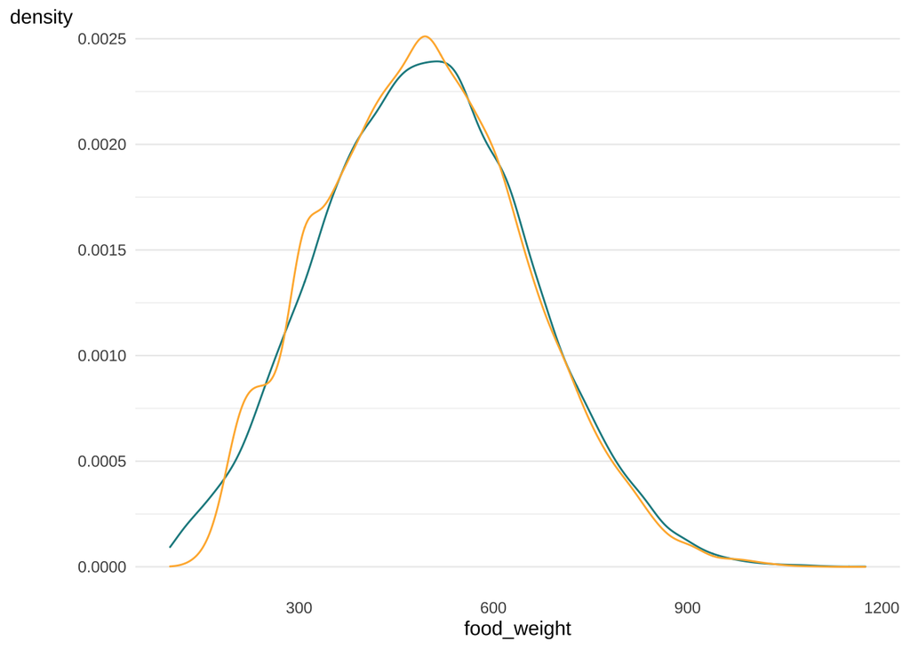

```r
ggplot(df) + geom_density(aes(x  = food_weight, color = meat_fish))+
  scale_color_trr266_d() +
  theme_trr()
```

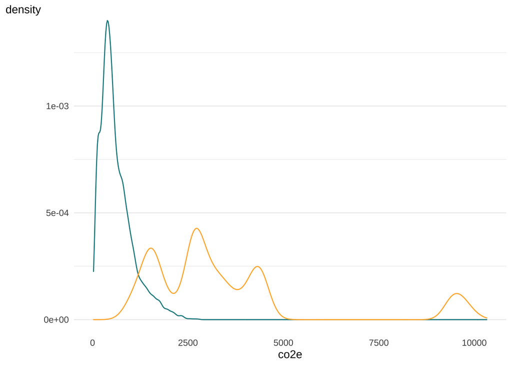

```r
ggplot(df) + geom_density(aes(x  = co2e, color = meat_fish)) +
  scale_color_trr266_d() +
  theme_trr()
```